# Reproducible Research - Project 1

Siddhartha Garg

10-Nov-2018

# Introduction

```r
# Setup the environment
library("dplyr")
```

```r
library("ggplot2")
knitr::opts_chunk$set(warning=FALSE)

# Setup the file
download.file("https://d396qusza40orc.cloudfront.net/repdata%2Fdata%2Factivity.zip", "s05_w02.zip")
unzip("s05_w02.zip")
file <- read.csv("activity.csv")

# Process the file
file_tb <- tbl_df(file)
file_tb <-
file_tb %>%
  filter(steps != "NA") %>%
  mutate(date = as.Date(date, format = "%Y-%m-%d"))

file_tb_daily <-
  file_tb %>%
  group_by(date) %>%
  summarise(steps = sum(steps))
```

# Analysis without imputing values

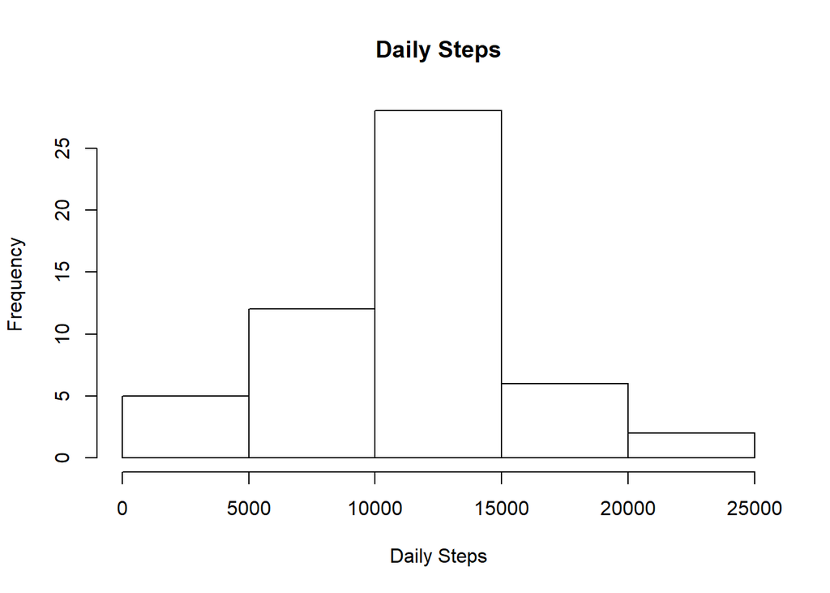

```r
hist(file_tb_daily$steps , main = "Daily Steps", xlab = "Daily Steps")
```

```r
sprintf("Mean of Daily steps %.1f", mean(file_tb_daily$steps))
```

```
## [1] "Mean of Daily steps 10766.2"
```

```r
sprintf("Median of Daily steps %.0f", median(file_tb_daily$steps))
```

```
## [1] "Median of Daily steps 10765"
```

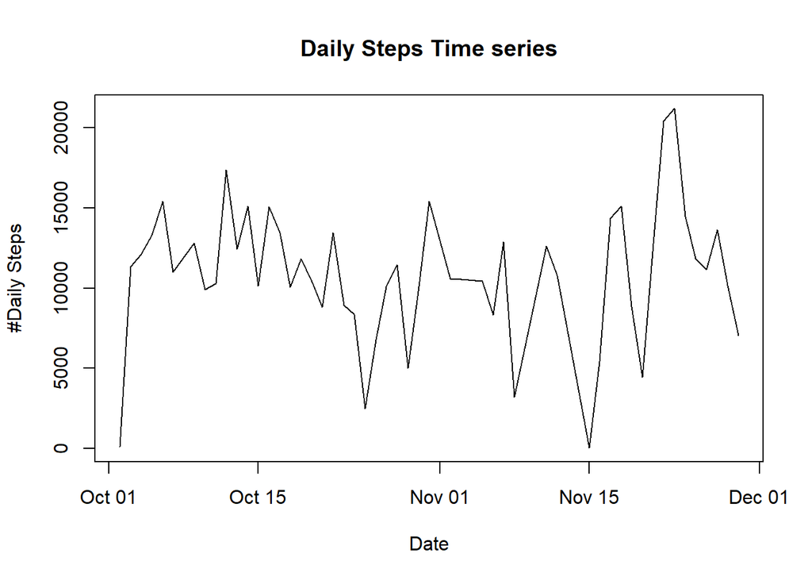

```r
plot(file_tb_daily$date, file_tb_daily$steps, type = "l", main = "Daily Steps Time series", xlab = "Date", ylab = "#Daily Steps")
```

## Analysis by 5 min internal

```r
file_tb_interval <-
  file_tb %>%
  group_by(interval) %>%
  summarise(max_int = max(steps)) %>%
  arrange(desc(max_int))
sprintf("Max Interval is %d with max steps %d", file_tb_interval[[1]][[1]], file_tb_interval[[1]][[2]])
```

[output not shown]

## What is the average daily activity pattern?

### Q1. Make a time series plot of the 5-minute interval (x-axis) and the average number of steps taken, averaged across all days (y-axis)

[figure not shown]

```r
file_tb_interval2 <-
  file_tb %>%
  group_by(interval) %>%
  summarise(steps = mean(steps))
ggplot(file_tb_interval2, aes(x = interval, y=steps)) +
  labs(title = "Sum of Steps by Interval", x = "interval", y = "steps")+
  geom_line(color="red")
```

### Q2. Which 5-minute interval, on average across all the days in the dataset, contains the maximum number of steps?

```r
file_tb_interval2[which.max(file_tb_interval2$steps),]
```

```
## # A tibble: 1 x 2
##   interval steps
##      <int> <dbl>
## 1      835  206.
```

# Strategies for Imputing values

## Q1. Calculate and report the total number of missing values in the dataset (i.e. the total number of rows with NAs)

```r
nrow(file[which(is.na(file$steps)),])
```

```
## [1] 2304
```

## Q2. Devise a strategy for filling in all of the missing values in the dataset.

We will use the mean interval steps Use mean interval steps from Mean Steps for that interval.

```r
file_tb_na <- file[which(is.na(file$steps)),]
file_copy <- file
na_rows <- is.na(file_copy$steps)
mean_interval <- tapply(file$steps, file$interval, mean, na.rm=TRUE, simplify=TRUE)
file_copy$steps[na_rows] <- mean_interval[as.character(file_copy$interval[na_rows])]
```

### Make a histogram of the total number of steps taken each day and Calculate and report the mean and median total number of steps taken per day.

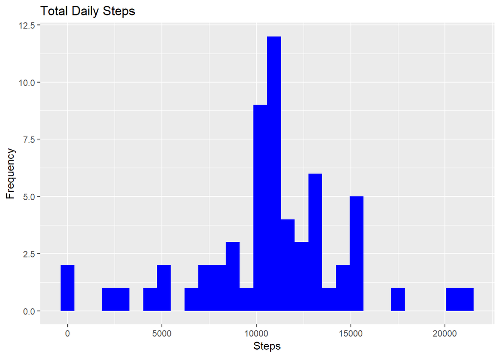

```r
# Process the file
file_copy_tb <- tbl_df(file_copy)
file_copy_tb_daily <-
  file_copy_tb %>%
  group_by(date) %>%
  summarise(steps = sum(steps))
ggplot(file_copy_tb_daily, aes(x = steps)) + geom_histogram(fill = "blue") + labs(title = "Total Daily Steps", x = "Steps", y = "Frequency")
```

```r
sprintf("Mean of Daily steps %.1f", mean(file_copy_tb_daily$steps))
```

```
## [1] "Mean of Daily steps 10766.2"
```

```r
sprintf("Median of Daily steps %.0f", median(file_copy_tb_daily$steps))
```

```
## [1] "Median of Daily steps 10766"
```

These median is higher than previous as we have added them mean values to missing data, which effectively increases the median, with no effect on mean itself.

### Are there differences in activity patterns between weekdays and weekends?

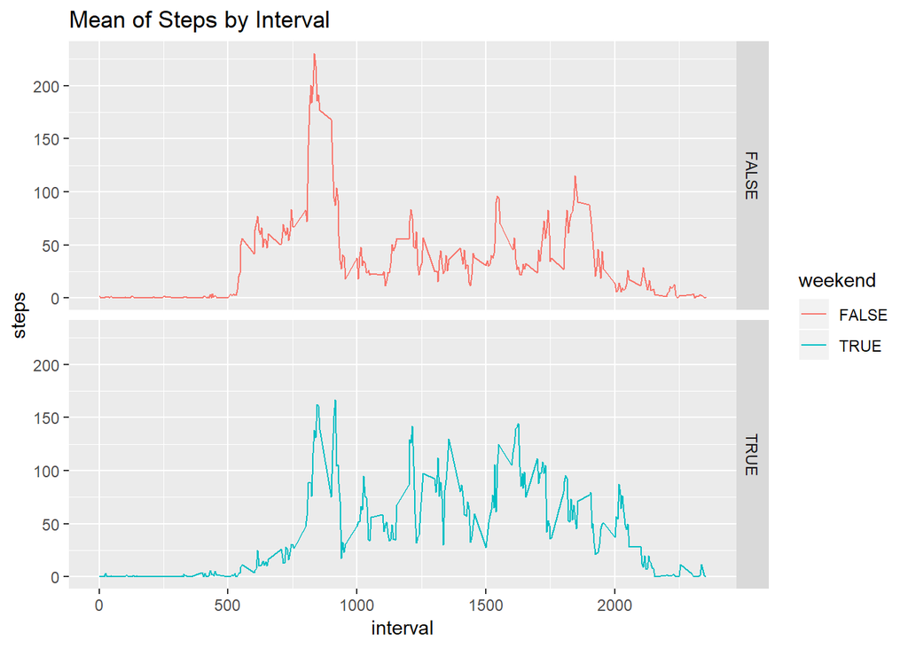

```r
file_copy_tb1 <-
  file_copy_tb %>%
    mutate(date = as.Date(date, format = "%Y-%m-%d"))  %>%
    mutate(day = weekdays(date)) %>%
    mutate(weekend = ifelse((day == "Saturday" | day == "Sunday"),TRUE,FALSE)) %>%
    group_by(interval, weekend) %>%
    summarize(steps = mean(steps))


ggplot(file_copy_tb1, aes(x = interval, y=steps, color=weekend)) +
  geom_line() +
  facet_grid(weekend ~ .) +
  labs(title = "Mean of Steps by Interval", x = "interval", y = "steps")
```